# Practica 2

## 2.5 Gráfico II

Se genera un gráfico de **Matriz de nube puntos** (*scatter plot matrix*) de la matriz de componentes principales. Para ello, se crea una variable **r**, que es el rango o *dimensión* de la matriz, y se utiliza la función *plot*.

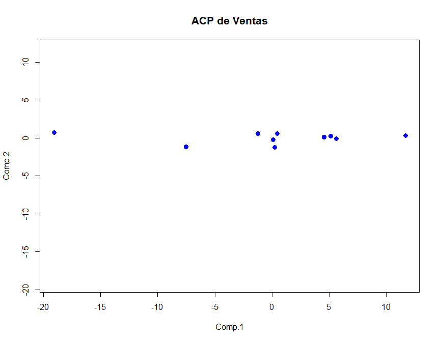

```r
r = with(scores, range(Comp.1));

plot(scores,
     pch = 19,
     cex = 1.2,
     upper.panel = NULL,
     col = 4 ,
     main = 'ACP de Ventas',
     cex.main = 1.3,
     xlim = r,
ylim = r);
```

Puede observarse en el gráfico, que prácticamente todos los valores se encuentran sobre una línea horizontal.

## 2.6 Caso tipificado

En este apartado se realiza una tipificación. Con esta transformación se intenta evitar problemas derivados de las diferentes escalas de los datos.

En el caso tipificado, se utiliza como matriz de covarianzas muestrales la **matriz de correlación muestral *R***.

$R = Z_i=(X_i-\bar{x})/\sqrt{s_{ii}},\ \ \ \ i=1,...,p$

En este apartado se utiliza, alternativamente, la función *“eigen”* del paquete *basis*, con la que se obtiene directamente los **autovalores** y **autovectores** de cualquier matriz cuadrada,

```r
eigen(R);
```

```
## $values
## [1] 1.7107028 0.2892972
##
## $vectors
##           [,1]       [,2]
## [1,] 0.7071068 -0.7071068
## [2,] 0.7071068  0.7071068
```

Se crea el **vector de autovalores *k*** y la **matriz de autovectores *H*** para la nueva matriz de equicorrelación,

```r
K = with(eigen(R), values);
round(K,4);
```

```
## [1] 1.7107 0.2893
```

```r
H = with(eigen(R),vectors);
round(H,4);
```

```
##        [,1]    [,2]
## [1,] 0.7071 -0.7071
## [2,] 0.7071  0.7071
```

se calculan las **proporciones acumuladas**,

```r
round(cumsum(K/sum(K)),digits = 4);
```

```
## [1] 0.8554 1.0000
```

y se calculan las correlaciones de la primera componente principal con las variables ventas y beneficios,

```r
sqrt(K[1]*H[,1]);
```

```
## [1] 1.099841 1.099841
```

## 2.7 Conclusiones

Como las proporciones son 0.855 y 1, las correlaciones entre la CP y las dos variables son iguales, ya que el autovector es constante.

Por otro lado, el valor de las componentes sería,

```
cp.1 = 0.7071 x ventas + 0.7071 x beneficio
cp.2 =-0.7071 x ventas + 0.7071 x beneficio
```

Estos coeficientes son los senos y los cosenos del ángulo de rotación entre los ejes de los CP y los ejes de las variables tipificadas.

En este caso lo correcto es utilizar la tipificación de los datos para evitar el problema de la escala. Se puede deducir comprobando que el valor de la columna *ventas* que es mayor que el de la columna *beneficios*.

# 3 Ejercicio [2]

En este ejercicio se realiza un análsis de componentes princiaples para el conjunto de datos *sctkpr.txt*. Este dataset contiene los datos semanales de retornos sobre opciones de cinco compañías:

- AC: Allied Chemical.(Química)
- DP: Du Pont. (Química)
- UC: Union Carbide.(Química)
- EX: Exxon. (Petrolera)
- TX: Texaco. (Petrolera)

## 3.1 Carga y descripción de los datos

```r
data.1 = read.table('stckpr.txt', header = TRUE);
head(data.1)
```

```
##         AC        DP        UC        EX        TX
## 1 0.000000  0.000000  0.000000  0.039473  0.000000
## 2 0.027027 -0.044855 -0.003030 -0.014466  0.043478
## 3 0.122807  0.060773  0.088146  0.086238  0.078124
## 4 0.057031  0.029948  0.066808  0.013513  0.019512
## 5 0.063670 -0.003793 -0.039788 -0.018644 -0.024154
## 6 0.003521  0.050761  0.082873  0.074265  0.049504
```

**Diagrama de dispersión**

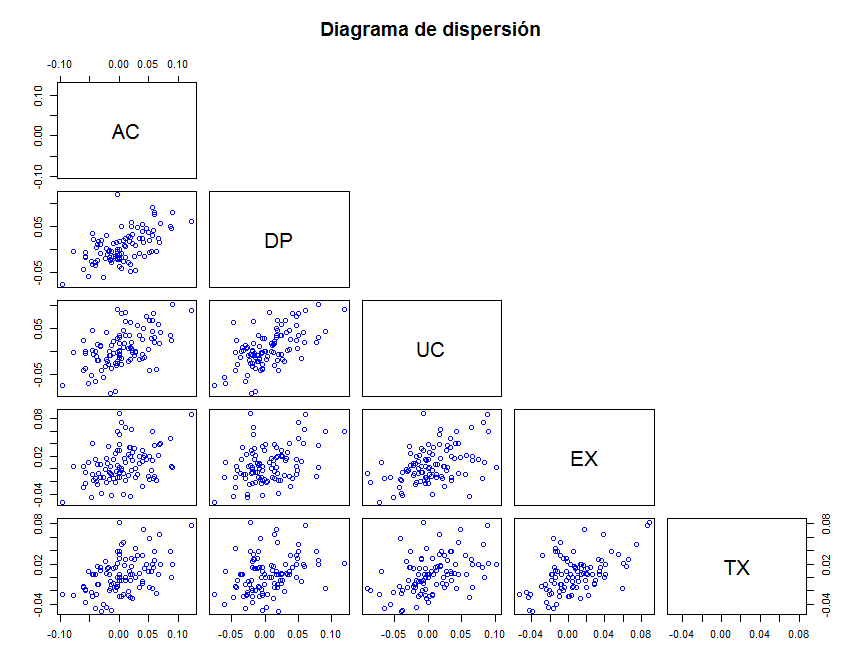

```r
plot(data.1, upper.panel = NULL,
     main= "Diagrama de dispersión",
     col = 4)
```

**Matriz de covarianza**

```r
S = cov(data.1);
round(S, digits = 4);
```

```
##        AC     DP     UC    EX    TX
## AC 0.0016 0.0008 0.0008 4e-04 5e-04
## DP 0.0008 0.0012 0.0008 4e-04 3e-04
## UC 0.0008 0.0008 0.0016 5e-04 5e-04
## EX 0.0004 0.0004 0.0005 8e-04 4e-04
## TX 0.0005 0.0003 0.0005 4e-04 8e-04
```

**Autovalores y autovectores**

```r
eigen(S);
```

```
## $values
## [1] 0.0035953867 0.0007921798 0.0007364426 0.0005086686 0.0003437707
##
## $vectors
##            [,1]        [,2]       [,3]        [,4]        [,5]
## [1,] -0.5605914  0.73884565 -0.1260222  0.28373183 -0.20846832
## [2,] -0.4698673 -0.09286987 -0.4675066 -0.68793190  0.28069055
## [3,] -0.5473322 -0.65401929 -0.1140581  0.50045312 -0.09603973
## [4,] -0.2908932 -0.11267353  0.6099196 -0.43808002 -0.58203935
## [5,] -0.2842017  0.07103332  0.6168831  0.06227778  0.72784638
```

**Variación Total**

```r
L = with(eigen(S), values);
L/sum(L);
```

```
## [1] 0.60159252 0.13255027 0.12322412 0.08511218 0.05752091
```

Ante estos resultados es destacable que los autovalores son bajos, debido a un problema de unidades de media. Es decir, no hay problema de varianzas dominantes, sino un problema de unidades, para solventarlo se multiplica por 100 para expresar los retornos semanales en forma de porcentaje.

## 3.2 Cambio de unidades

Se multiplican los datos por 100 y se recalcula la **matriz de covarianzas muestrales**,

```r
S = cov(100*data.1);
round(S, digits = 4);
```

```
##         AC      DP      UC     EX     TX
## AC 16.2993  8.1667  8.1007 4.4224 5.1397
## DP  8.1667 12.2938  8.2763 3.8686 3.1094
## UC  8.1007  8.2763 15.5608 4.8728 4.6248
## EX  4.4224  3.8686  4.8728 8.0233 4.0847
## TX  5.1397  3.1094  4.6248 4.0847 7.5874
```

Calculo de las **desviaciones típicas** como la raíz de la diagonal principal de la matriz de covarianzas,

```r
round(sqrt(diag(S)), digits = 4);
```

```
##     AC     DP     UC     EX     TX
## 4.0372 3.5062 3.9447 2.8325 2.7545
```

los **autovalores** y **autovectores**

```r
eigen(S);
```

```
## $values
## [1] 35.953867  7.921798  7.364426  5.086686  3.437707
##
## $vectors
##            [,1]        [,2]       [,3]        [,4]        [,5]
## [1,] -0.5605914  0.73884565 -0.1260222  0.28373183 -0.20846832
## [2,] -0.4698673 -0.09286987 -0.4675066 -0.68793190  0.28069055
## [3,] -0.5473322 -0.65401929 -0.1140581  0.50045312 -0.09603973
## [4,] -0.2908932 -0.11267353  0.6099196 -0.43808002 -0.58203935
## [5,] -0.2842017  0.07103332  0.6168831  0.06227778  0.72784638
```

**Variación Total**

```r
L = with(eigen(S), values);
L/sum(L);
```

```
## [1] 0.60159252 0.13255027 0.12322412 0.08511218 0.05752091
```

**Matriz de correlaciones**

```r
R = cor(data.1);
round(R, digits = 4);
```

```
##        AC     DP     UC     EX     TX
## AC 1.0000 0.5769 0.5087 0.3867 0.4622
## DP 0.5769 1.0000 0.5984 0.3895 0.3220
## UC 0.5087 0.5984 1.0000 0.4361 0.4256
## EX 0.3867 0.3895 0.4361 1.0000 0.5235
## TX 0.4622 0.3220 0.4256 0.5235 1.0000
```

En este punto pueden calcularse las *correlaciones mínima* y *máxima*. Para la máxima, previamente se resta una matriz identidad de tamaño n, para que no se utilicen los valores iguales a uno,

```r
round(c(min(R),max(R - diag(ncol(data.1)))), digits = 4);
```

```
## [1] 0.3220 0.5984
```

La correlación entre todas las variables es positiva y se encuentra entre los valores 0.3 y 0.6.

## 3.3 Caso tipificado

Para calcular el caso tipificado, se calculan los **autovalores** y **autovectores** sobre la matriz de correlaciones muestrales,

```r
eigen(R);
```

```
## $values
## [1] 2.8564869 0.8091185 0.5400440 0.4513468 0.3430038
##
## $vectors
##            [,1]       [,2]       [,3]       [,4]       [,5]
## [1,] -0.4635405  0.2408499  0.6133570 -0.3813727 -0.4532876
## [2,] -0.4570764  0.5090997 -0.1778996 -0.2113068  0.6749814
## [3,] -0.4699804  0.2605774 -0.3370355  0.6640985 -0.3957247
## [4,] -0.4216770 -0.5252647 -0.5390181 -0.4728036 -0.1794482
## [5,] -0.4213291 -0.5822416  0.4336029  0.3812273  0.3874672
```

Y se obtienen las **proporciones de variación explicada** de la matriz tipificada y comparada con las proporciones sin tipificar,

```r
K = with(eigen(R), values);
K/sum(K);
```

```
## [1] 0.57129738 0.16182370 0.10800880 0.09026936 0.06860076
```

```r
L/sum(L);
```

```
## [1] 0.60159252 0.13255027 0.12322412 0.08511218 0.05752091
```

Práctimente son iguales, ya que los valores de retornos (logaritmos de las diferencias) se encuentran en la misma escala.

## 3.4 Reducción de la dimensión

En este apartado se trabaja con el objetivo del ACP, la reducción de la dimensión para realizar un resumen de los datos. En primer lugar, se calcula la proporción de variación y proporción acumulada, mostrándose luego en una única matriz de variación explicada.

```r
prop = K/sum(K);
acum = cumsum(prop);
table = round(data.frame(S,prop,acum, row.names = NULL ),digits = 4);
```

**Proporciones**

```r
prop;
```

```
## [1] 0.57129738 0.16182370 0.10800880 0.09026936 0.06860076
```

**Proporciones acumuladas**

```r
acum;
```

```
## [1] 0.5712974 0.7331211 0.8411299 0.9313992 1.0000000
```

**Matriz de proporción explicada**

```r
table;
```

```
##        AC      DP      UC     EX     TX   prop   acum
## 1 16.2993  8.1667  8.1007 4.4224 5.1397 0.5713 0.5713
## 2  8.1667 12.2938  8.2763 3.8686 3.1094 0.1618 0.7331
## 3  8.1007  8.2763 15.5608 4.8728 4.6248 0.1080 0.8411
## 4  4.4224  3.8686  4.8728 8.0233 4.0847 0.0903 0.9314
## 5  5.1397  3.1094  4.6248 4.0847 7.5874 0.0686 1.0000
```

**Gráfico de sedimentación**

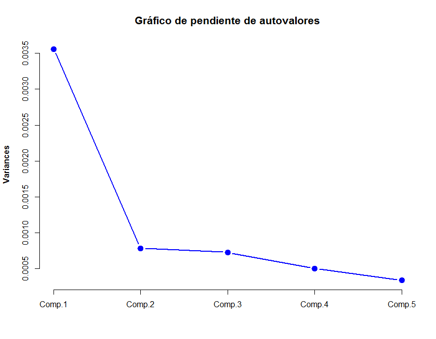

```r
pc = princomp(data.1);
plot(pc, type = 'l', col = 4,
pch = 19, lwd = 2.5, cex = 1.5,
main = 'Gráfico de pendiente de autovalores',
font.lab = 2,
cex.main = 1.3);
```

La determinación del número de componentes a retener es, en parte, arbitraria y queda a juicio del investigador. Un criterio, por ejemplo, sería retener los factores con autovalor superior a 1. Con ese criterio la segunda componente no sería elegida.

Otra operación en el ACP, es reducir la dimensionalidad de las variables, desechando las variables (compañías) menos informativas entre las originales de nuestro estudio. [Joliffe (1972, 1973)](https://scholar.google.co.uk/citations?user=JdqoVEkAAAAJ&hl=en) ha propuesto un método para ello que consiste en reducir directamente las variables originales al número de ellas que cumplan con los siguientes requisitos:

Según lo cual, se trabajaría exclusivamente con las compañías UC, TX y Ac.

En el siguiente apartado se exploran otro tipo de gráficos para estudiar la carga de las componentes y la proximidad entre observaciones y variables, de forma de averiguar si arrojan más información sobre la reducción de la dimensión.

## 3.5 Otros gráficos

En esta sección, y a modo ilustrativo, se utiliza la función *“prcomp”* para el ACP, también incluida en el paquete *stats*, creando el objeto *acp* que dota con la información a los gráficos.

Se obtienen las desviaciones standard de las componentes principales y el elemento *Rotation* que son los **autovectores**, el equivalente a *loadings* de la función *“princomp”*.

```r
(acp = prcomp(data.1));
```

```
## Standard deviations:
## [1] 0.05996154 0.02814569 0.02713748 0.02255368 0.01854106
##
## Rotation:
##          PC1         PC2        PC3         PC4         PC5
## AC 0.5605914  0.73884565 -0.1260222  0.28373183 -0.20846832
## DP 0.4698673 -0.09286987 -0.4675066 -0.68793190  0.28069055
## UC 0.5473322 -0.65401929 -0.1140581  0.50045312 -0.09603973
## EX 0.2908932 -0.11267353  0.6099196 -0.43808002 -0.58203935
## TX 0.2842017  0.07103332  0.6168831  0.06227778  0.72784638
```

Se puede trabajar usando datos reescalados, indicando a la función el valor lógico *scale*, para tener una varianza unitaria antes de que se realice el análisis.

```r
(acp.r = prcomp(data.1, scale = TRUE));
```

```
## Standard deviations:
## [1] 1.6901145 0.8995101 0.7348768 0.6718235 0.5856653
##
## Rotation:
##          PC1        PC2        PC3        PC4        PC5
## AC 0.4635405 -0.2408499  0.6133570 -0.3813727  0.4532876
## DP 0.4570764 -0.5090997 -0.1778996 -0.2113068 -0.6749814
## UC 0.4699804 -0.2605774 -0.3370355  0.6640985  0.3957247
## EX 0.4216770  0.5252647 -0.5390181 -0.4728036  0.1794482
## TX 0.4213291  0.5822416  0.4336029  0.3812273 -0.3874672
```

Los **autovalores** se obtienen como:

```r
acp$sdev^2;
```

```
## [1] 0.0035953867 0.0007921798 0.0007364426 0.0005086686 0.0003437707
```

Mediante un resumen del objeto *acp* es sencillo obtener la **proporción de la varianza explicada** y su **acumulación** como en los apartados anteriores,

```r
summary(acp);
```

```
## Importance of components:
##                            PC1     PC2     PC3     PC4     PC5
## Standard deviation     0.05996 0.02815 0.02714 0.02255 0.01854
## Proportion of Variance 0.60159 0.13255 0.12322 0.08511 0.05752
## Cumulative Proportion  0.60159 0.73414 0.85737 0.94248 1.00000
```

Es interesante en el análisis gráfico, calcular las **correlaciones** entre las variables y las componentes,

```r
(corvar = acp.r$rotation %*% diag(acp.r$sdev));
```

```
##         [,1]       [,2]       [,3]       [,4]       [,5]
## AC 0.7834366 -0.2166469  0.4507418 -0.2562151  0.2654748
## DP 0.7725114 -0.4579403 -0.1307343 -0.1419609 -0.3953132
## UC 0.7943207 -0.2343920 -0.2476796  0.4461570  0.2317622
## EX 0.7126824  0.4724809 -0.3961119 -0.3176406  0.1050966
## TX 0.7120945  0.5237322  0.3186447  0.2561175 -0.2269261
```

La función *prcomp* devuelve, además, el valor de los datos rotados *x* , es decir, los datos centrados multiplicados por la matriz de rotación,

```r
head(acp.r$x);
```

```
##             PC1        PC2        PC3        PC4        PC5
## [1,]  0.2445649  0.6767803 -0.6995557 -0.6199562  0.2375746
## [2,] -0.2038989  1.1056309  1.6753642  0.8461270  0.4208211
## [3,]  5.3881808  0.9980347  0.4446003 -0.3616913  0.5280689
## [4,]  1.9977323 -0.6085663  0.2452845  0.4889131  0.5326489
## [5,] -0.7825238 -0.9734296  1.3526574 -1.2326002  0.5978952
## [6,]  3.2092324  1.0628780 -1.4944836  0.5404445 -0.3446589
```

**Gráfico de la proporción de la varianza**

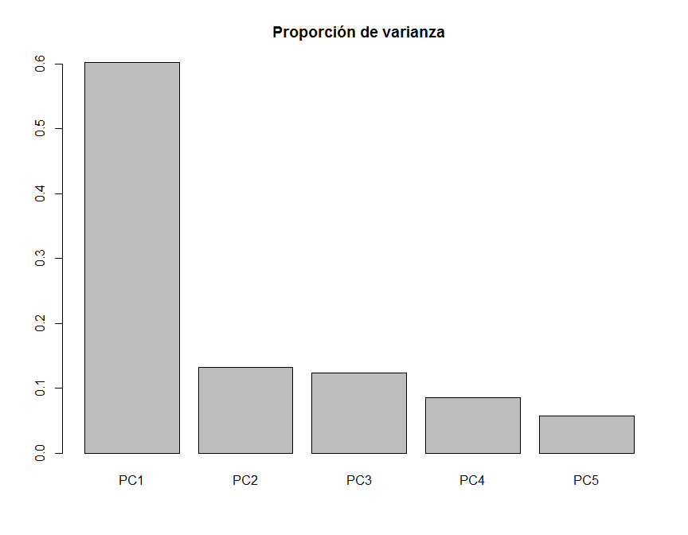

```r
barplot(summary(acp)$importance[2, ], main =  "Proporción de varianza");
```

**Gráfico de correlación entre las variables y las CP1 y CP2**

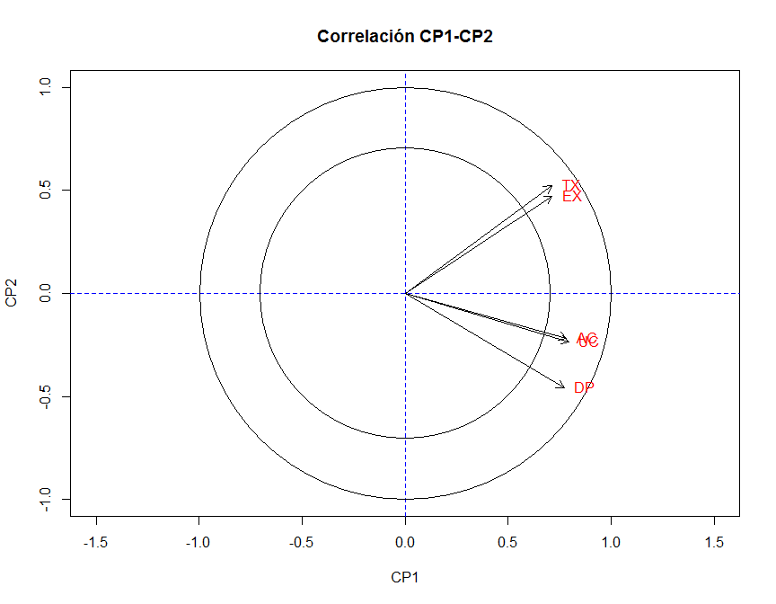

```r
plot(-1:1, -1:1, main = "Correlación CP1-CP2",
     type ='n',
     asp = 1,
     xlab = 'CP1',
     ylab = 'CP2');

abline(h = 0, v = 0, lty = 2, col = 4);

## Dibuja un círculo de centro (0,0) y radio 1
symbols(0, 0, 1, inches = F, add = T);
symbols(0, 0, sqrt(.5), inches = F, add = T);

## Dibuja los vectores y coloca los nombres
arrows(0, 0, corvar[,1], corvar[,2], length = .1);
text(corvar[,1], corvar[,2], colnames(data.1), pos=4, offset = .6, col = 2, font = 0.3);
```

En el primer cuadrante se observa que TX y EX (petroleras) son mayores que cero, mientras que AC, DP y UC (químicas) son negativas para la CP2. Todas las flechas tienen el mismo tamaño, por tanto los coeficientes son similares.

**Gráfico de los individuos**

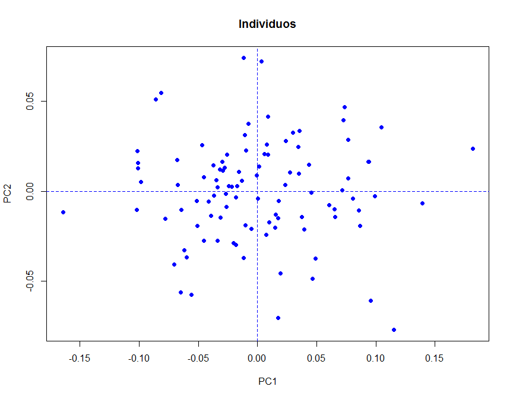

```r
plot(acp$x[, 1:2],
     main = "Individuos",
     pch = 19,
     col= 4);
abline(h = 0, v = 0, lty = 2, col = 4);
```

**Gráfico Bliplot**

Los [**Biplots**](https://es.wikipedia.org/wiki/Biplot) son un tipo de gráfico exploratorio usado en Estadística. Se trata de una generalización multivariante de un diagrama de dispersión de dos variables. De la misma manera que un diagrama de dispersión muestra la distribución conjunta de dos variables, un Biplot representa tres o más variables. El biplot aproxima la distribución de una muestra multivariante en un espacio de dimensión reducida, normalmente de dimensión dos, y superpone sobre la misma representaciones de las variables sobre las que se mide la muestra.

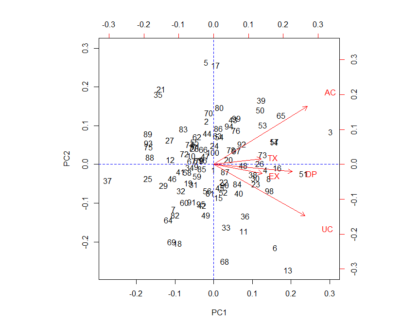

```r
biplot(acp);
abline(h = 0, v = 0, lty = 2, col = 4);
```

**Gráfico de barras para la Correlación CP y las Variables**

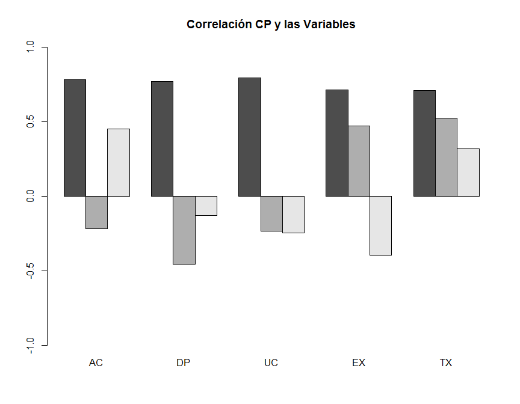

```r
data.cor = acp.r$rotation %*% diag(acp.r$sdev);
barplot(t(data.cor[,1:3]),beside = TRUE, main= "Correlación CP y las Variables",ylim = c(-1,1));
```

## 3.6 Conclusiones

El objeto de este análisis es averiguar si existe algún tipo de relación entre los valores de los retornos de las opciones de las cinco compañías, tres dedicadas a la industria química y dos pretroleras.

Estos resultados coinciden con [Benjamin F.King, 1966](http://www.jstor.org/stable/2351742) donde, mediante diversos métodos de análisis factorial aplicados a los datos dan un apoyo notable a la hipótesis de que el movimiento de un grupo de cambios de precios de materias primas puede desglosarse en componentes del mercado y de la industria. Intenta identificar el agrupamiento de la industria mediante un control de los signos de carga de los componentes principales.

# 4 Ejercicio [3]

En este ejercicio se realiza un análsis de componentes princiaples para el conjunto de datos *DJ*. Del cual querconsideranr los retornos asociados a los valores diarios de cierre del índice bursátil Dow Jones durante los años 1992-1998 para las empresas:

- MO: Philip Morris
- KO: Coca Cola
- EK: Kodak
- HWP: Hewlett Packard
- INTC’:Intel
- MSFT: Microsoft
- MCD: McDonald’s
- WMT: Walmart
- DIS: Disney

## 4.1 Carga y descripción de los datos

En primer lugar, es necesario instalar los paquetes y las dependencias para trabajar con el conjunto de datos **DJ**,

```
install.packages("QRM");
library(QRM);

#paquete para graficar:
library (zoo)
#para comprobar los paquetes instalados:
search();
```

y en segundo lugar, cargar el conjunto de datos,

```r
library(QRM);
library (zoo);
data(DJ);
```

se crea una variable vacía con los datos del índice dowjones. Para obtener los datos se deben llamar desde la memoria de ejecución. Por ejemplo, se crea una variable data.ini con todos los datos de **DJ** y se comprueba su tamaño (*filas x columnas*):

```
dim(data.ini);
```

Se genera un vector con las cabeceras o nombres de las variables de interés.

```r
I = c('MO', 'KO', 'EK', 'HWP', 'INTC', 'MSFT', 'IBM', 'MCD', 'WMT', 'DIS');
```

Se utiliza la función *“window”* del paquete *timeseries* que permite extraer los **valores** para unas fechas dadas por el ejercicio.

```r
data.S = window(DJ[,I],'1992-01-01','1998-12-31');
```

Mediante la función *“returs”* se calculan los **retornos**, que pueden ser continuos o discretos. En este caso se trabaja sobre datos discretos.

```r
data.0 = returns(data.S, method = 'discrete');
```

**Gráficos**

Se crea una matriz de gráficos para mostrar la serie temporal de cada compañía.

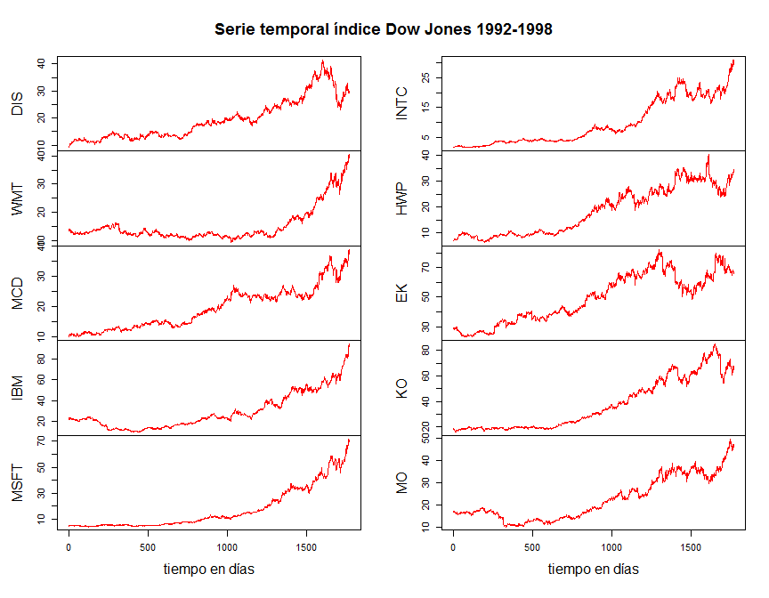

```r
plot.zoo(data.S[,10:1],
  main = 'Serie temporal índice Dow Jones 1992-1998',
  xlab = 'tiempo en días',
  col = 'red',
  cex.main = 1.75);
```

Y para mostrar la matriz de gráficos de los retornos.

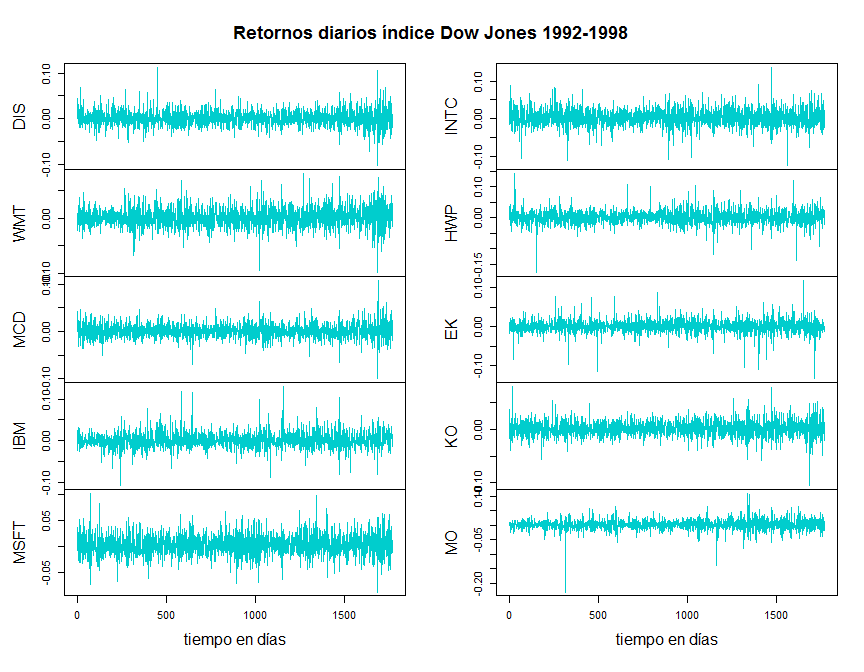

```r
plot.zoo(data.0[,10:1],
  main = 'Retornos diarios índice Dow Jones 1992-1998',
  xlab = 'tiempo en días',
  col = 'cyan3',
  cex.main = 1.75);
```

Se realiza una transformación de los datos, multiplicándolos por 100 para pasarlos a %.

```r
data.1 = 100*data.frame(data.0);
str(data.1);
```

```
## 'data.frame':    1769 obs. of  10 variables:
##  $ MO  : num  -0.157 -0.157 0 0.945 0.936 ...
##  $ KO  : num  3.739 -0.301 -0.903 -1.824 -0.928 ...
##  $ EK  : num  -1.523 0.773 1.023 -0.506 -1.781 ...
##  $ HWP : num  0.895 -0.222 -0.445 3.572 3.448 ...
##  $ INTC: num  -0.493 -1.499 4.566 1.455 2.395 ...
##  $ MSFT: num  -0.878 3.099 3.004 3.542 2.414 ...
##  $ IBM : num  0.138 2.075 2.574 -2.378 -1.218 ...
##  $ MCD : num  0.318 2.222 2.174 0 4.256 ...
##  $ WMT : num  -2.326 -1.732 -0.44 0.885 0 ...
##  $ DIS : num  2.697 0.884 0.104 2.083 4.489 ...
```

Se realiza un diagrama de nube de puntos. Una caracteristica curiosa de este tipo de datos, retornos diarios, es la “asimetría de las colas” que es observable gráficamente

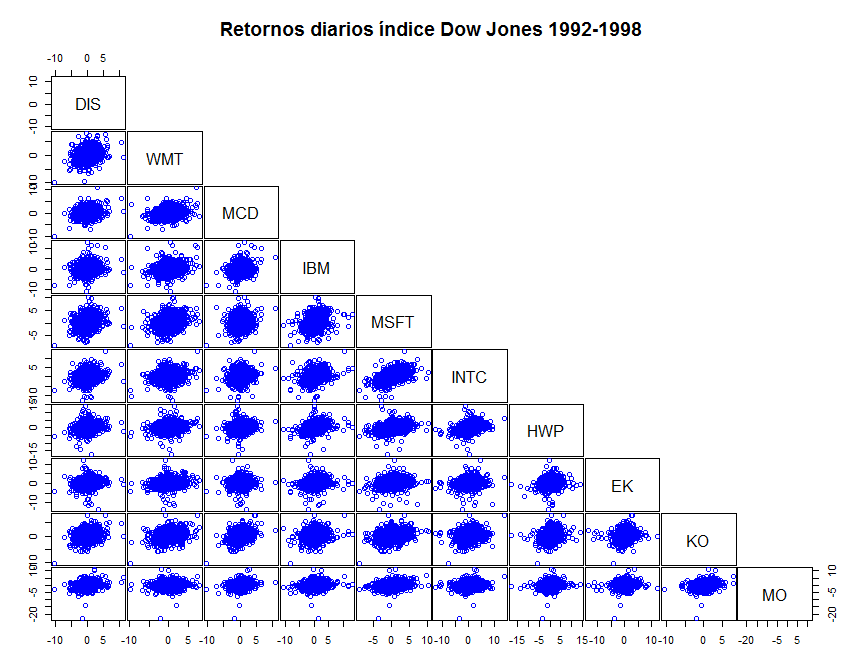

```r
plot(data.1[10:1], upper.panel = NULL,
  main = 'Retornos diarios índice Dow Jones 1992-1998',
  col = 4,
  labels = colnames(data.1[10:1]),
  cex.labels = 1.5,
gap = .15);
```

Con la raíz de la diagonal principal de matriz de covarianzas, se obtienen las desviaciones típicas de los **retornos**,

```r
round(sqrt(diag(cov(data.1))), digits = 4);
```

```
##     MO     KO     EK    HWP   INTC   MSFT    IBM    MCD    WMT    DIS
## 1.7738 1.4801 1.7146 2.2456 2.3315 2.0620 1.9161 1.5213 1.7756 1.7033
```

## 4.2 Componentes principales

Se crea el objeto *pc* para hacer la matriz de componentes principales sobre la matriz *data.1* y se comprueba su estructura y elementos,

```r
pc = princomp(data.1);
#Estructura: str(pc);
#Elementos:
ls(pc);
```

```
## [1] "call"     "center"   "loadings" "n.obs"    "scale"    "scores"
## [7] "sdev"
```

Las descripciones de la función *“princomp”* se desarrolla en el apartado [2.4](http://127.0.0.1:24136/rmd_output/2/#componentes-principales).

Por ejemplo, para comprobar las coordenadas de los autovectores:pc$loadings, se utiliza el operador de extracción **[,]**:

```r
round(pc$loadings[,1:6],digits = 4);
```

```
##       Comp.1  Comp.2  Comp.3  Comp.4  Comp.5  Comp.6
## MO   -0.1975 -0.3949  0.0885  0.6219  0.4807 -0.1005
## KO   -0.1913 -0.3429 -0.0004 -0.0813  0.0539  0.0894
## EK   -0.1639 -0.2260 -0.0313 -0.0621 -0.3389 -0.8949
## HWP  -0.4528  0.2542 -0.7607 -0.1753  0.3302 -0.0683
## INTC -0.5115  0.4547  0.4582 -0.0944 -0.0125 -0.0278
## MSFT -0.4356  0.1014  0.3808  0.0130  0.1630 -0.0170
## IBM  -0.3203  0.0656 -0.2328  0.5561 -0.6703  0.2633
## MCD  -0.1782 -0.3104 -0.0151 -0.0140  0.0008  0.1477
## WMT  -0.2381 -0.3927  0.0537 -0.4746 -0.2525  0.2571
## DIS  -0.2239 -0.3727 -0.0158 -0.1681  0.0483  0.1342
```

Y para comprobar la matriz de componentes principales, se extraen las primeras filas y columnas evitando mostrar todos los datos,

```r
round(pc$scores[1:10,1:6],digits = 3)
```

```
##            Comp.1 Comp.2 Comp.3 Comp.4 Comp.5 Comp.6
## 1992-01-03 -0.006 -1.125 -1.463  0.292  1.424  1.530
## 1992-01-06 -1.017 -0.619 -0.050  1.893 -0.814 -0.149
## 1992-01-07 -4.217  1.992  2.835  1.286 -1.719 -0.242
## 1992-01-08 -3.225  1.034 -0.084 -2.044  3.736 -0.267
## 1992-01-09 -4.577 -0.495 -0.369 -1.524  3.541  1.986
## 1992-01-10  4.089  0.465  0.608  0.050 -1.202 -0.121
## 1992-01-13 -1.205  0.816  0.910 -1.992 -0.002  0.470
## 1992-01-14 -5.492 -1.920 -1.805 -0.632 -1.010 -0.232
## 1992-01-15 -4.113  4.610 -1.916  0.039 -1.376 -0.300
## 1992-01-16 -0.209  7.917  3.355 -1.051 -1.724 -0.203
```

## 4.3 Gráfico de pendiente

Se genera un gráfico de pendiente o de *sedimentación*

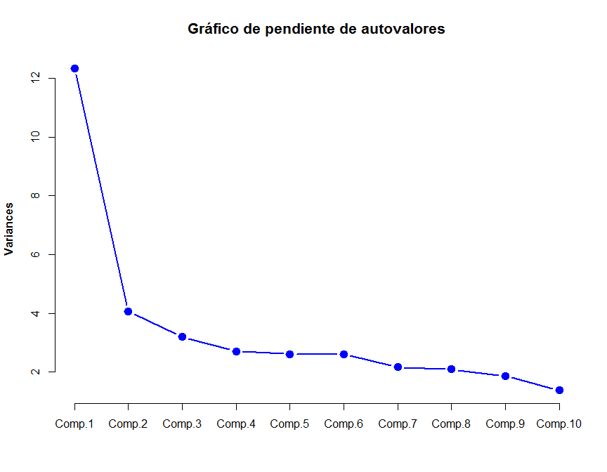

```r
plot(pc, type = 'l', col = 4,
  pch = 19, lwd = 2.5, cex = 1.5,
  main = 'Gráfico de pendiente de autovalores',
  font.lab = 2,
 cex.main = 1.3);
```

## 4.4 Autovectores

Se crea el objeto *G* que contiene a la matriz de autovectores,

```r
G = loadings(pc)[,];
```

Se crea un gráfico de barras resumiendo los valores de los autovecotores que definen las dos primeras componentes principales

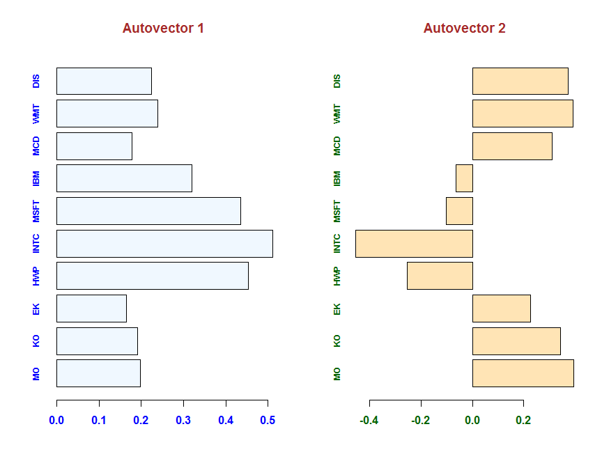

```r
par(mfrow = c(1,2));

barplot(-G[,1], horiz = TRUE, cex.names = 0.75, font = 2, col.axis = 'blue',
main = 'Autovector 1', col.main = 'brown', col = 'aliceblue');

barplot(-G[,2], horiz = TRUE, cex.names = 0.75, font = 2, col.axis = 'darkgreen',
main = 'Autovector 2', col.main = 'brown', col = 'moccasin');
```

A continuación se realiza el mismo gráfico, pero dividendo el primer autovector por la suma de coordenadas.

```r
round(-G[,1], digits = 4);
```

```
##     MO     KO     EK    HWP   INTC   MSFT    IBM    MCD    WMT    DIS
## 0.1975 0.1913 0.1639 0.4528 0.5115 0.4356 0.3203 0.1782 0.2381 0.2239
```

```r
round(-G[,1]/sum(-G[,1]), digits = 4);
```

```
##     MO     KO     EK    HWP   INTC   MSFT    IBM    MCD    WMT    DIS
## 0.0678 0.0657 0.0563 0.1554 0.1756 0.1495 0.1099 0.0612 0.0817 0.0769
```

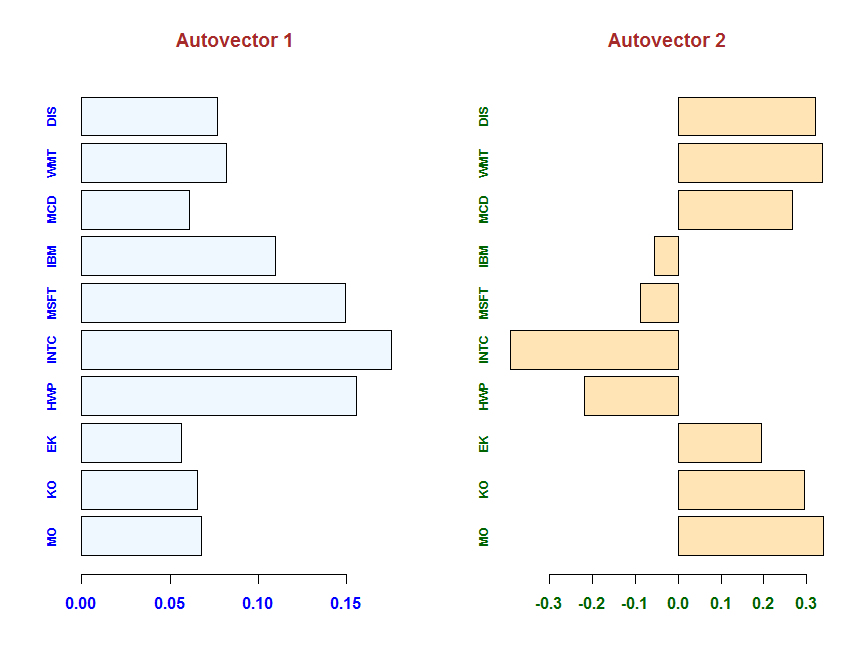

```r
par(mfrow = c(1,2));

barplot((-G[,1]/sum(-G[,1])), horiz = TRUE, cex.names = 0.75, font = 2, col.axis = 'blue',
main = 'Autovector 1', col.main = 'brown', col = 'aliceblue');

barplot(-G[,2]/sum(-G[,2]), horiz = TRUE, cex.names = 0.75, font = 2, col.axis = 'darkgreen',
main = 'Autovector 2', col.main = 'brown', col = 'moccasin');
```

Y, a continuación, para los autovectores 3 y 4.

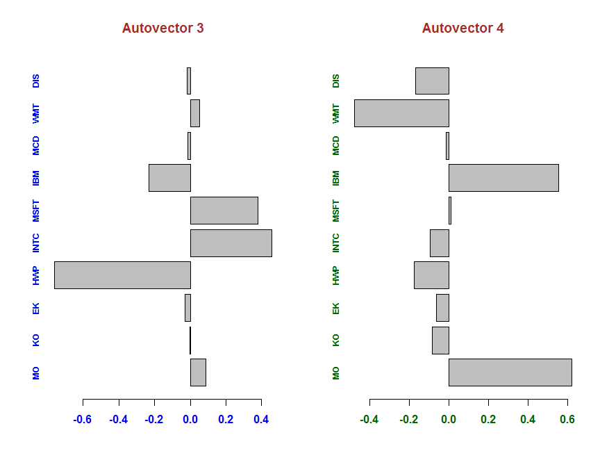

```r
par(mfrow = c(1,2));

barplot(G[,3], horiz = TRUE, cex.names = 0.75, font = 2, col.axis = 'blue',
main = 'Autovector 3', col.main = 'brown');

barplot(G[,4], horiz = TRUE, cex.names = 0.75, font = 2, col.axis = 'darkgreen',
main = 'Autovector 4', col.main = 'brown');
```

## 4.5 Importancia de componentes

En esta sección se genera una tabla que muestra la **varianza**, su **proporción** y su **proporción acumulada**, creando previamente los objetos correspondientes:

```r
var = with(summary(pc),sdev^2);
table = data.frame(var,var/sum(var),cumsum(var/sum(var)));
colnames(table) = c('var ','prop ','acum ');
round(table, digits = 4);
```

```
##            var   prop   acum
## Comp.1  12.3485 0.3525 0.3525
## Comp.2   4.0631 0.1160 0.4685
## Comp.3   3.1968 0.0913 0.5598
## Comp.4   2.7061 0.0773 0.6370
## Comp.5   2.6130 0.0746 0.7116
## Comp.6   2.6009 0.0743 0.7859
## Comp.7   2.1679 0.0619 0.8478
## Comp.8   2.0912 0.0597 0.9075
## Comp.9   1.8619 0.0532 0.9606
## Comp.10  1.3786 0.0394 1.0000
```

**Gráfico de correlación entre las variables y las CP1 y CP2**

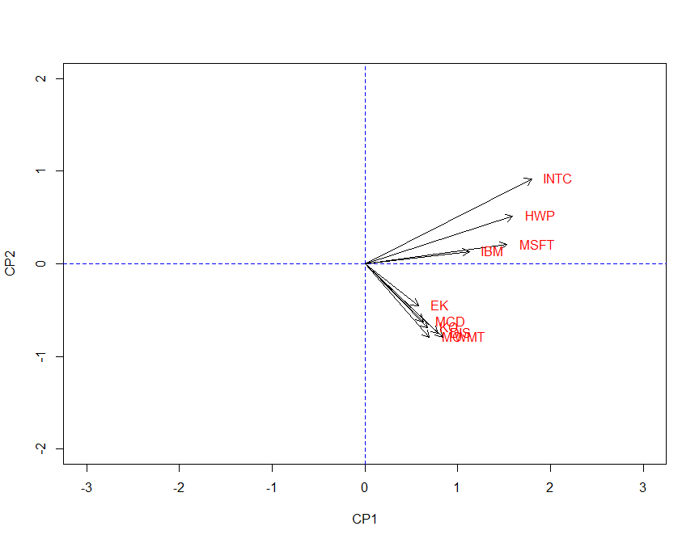

```r
#valores sin escalar
ancp = prcomp(data.1);
corvar_ancp = ancp$rotation %*% diag(ancp$sdev);

#gráfico
plot(-2:2, -2:2,
     type = 'n',
     asp = 1,
     xlab = 'CP1',
     ylab = 'CP2');
abline(h = 0, v = 0, lty = 2, col = 4);

arrows(0, 0, corvar_ancp[,1], corvar_ancp[,2], length = .1);
text(corvar_ancp[,1], corvar_ancp[,2], colnames(data.1), pos = 4, offset = .8, col = 2, font = 0.3);
```

Existe una relación positiva entre las tecnológicas y las dos primeras componentes principales,

**Gráfico de correlación entre las variables y las CP2 y CP3**

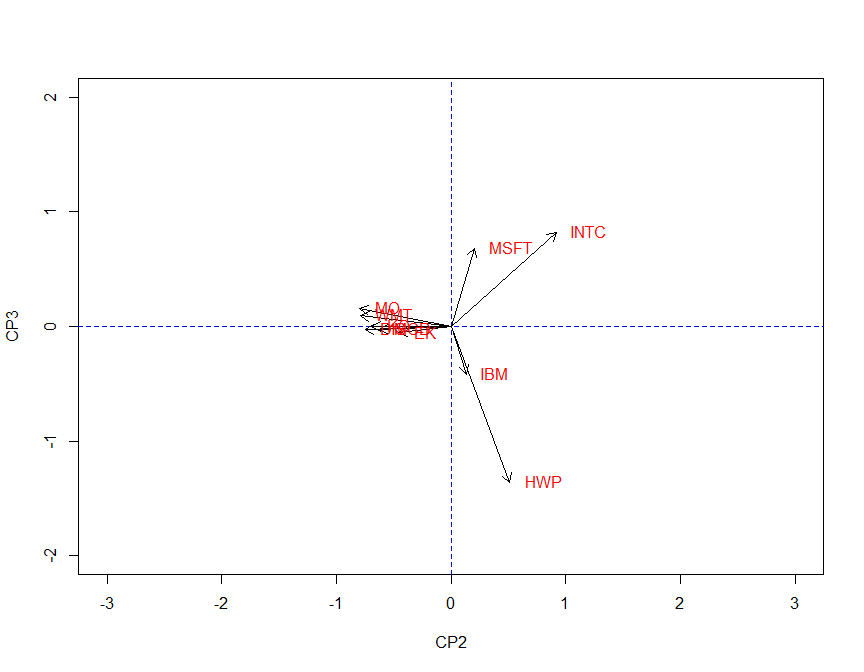

```r
#valores sin escalar
ancp = prcomp(data.1);
corvar_ancp = ancp$rotation %*% diag(ancp$sdev);

#gráfico
plot(-2:2, -2:2,
     type = 'n',
     asp = 1,
     xlab = 'CP2',
     ylab = 'CP3');
abline(h = 0, v = 0, lty = 2, col = 4);
arrows(0, 0, corvar_ancp[,2], corvar_ancp[,3], length = .1);
text(corvar_ancp[,2], corvar_ancp[,3], colnames(data.1), pos = 4, offset = .8, col = 2, font = 0.3);
```

Las direcciones se mantienen positivas en la CP3 para Microsoft e Intel.

**Gráfico de correlación entre las variables y las CP3 y CP4**

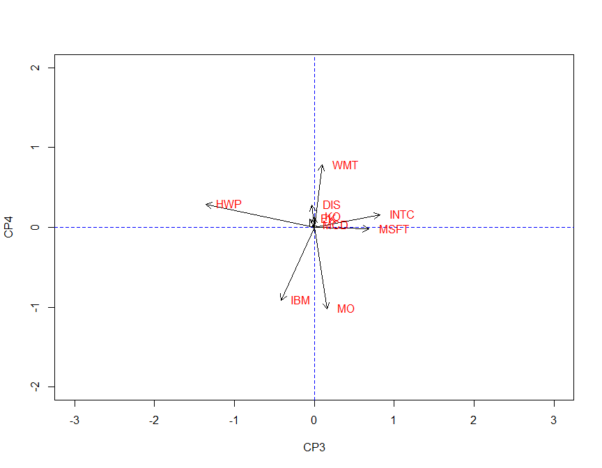

```r
#valores sin escalar
ancp = prcomp(data.1);
corvar_ancp = ancp$rotation %*% diag(ancp$sdev);

#gráfico
plot(-2:2, -2:2,
     type = 'n',
     asp = 1,
     xlab = 'CP3',
     ylab='CP4');
abline(h = 0, v = 0, lty = 2, col = 4);
arrows(0, 0, corvar_ancp[,3], corvar_ancp[,4], length=.1);
text(corvar_ancp[,3], corvar_ancp[,4], colnames(data.1), pos = 4, offset = .8, col = 2, font = 0.3);
```

No se observa una interpretación clara para las CP3 y CP4.

## 4.6 Diagrama de barras

Finalmente se muestra un gráfico de barras con las varianzas de todas las componentes principales. Para ello se crean dos matrices con los datos de la tabla de proporciones acumuladas,

```r
z = matrix(as.matrix(table[1]), nrow = 1);
u = matrix(as.matrix(table[3]), nrow = 1);
```

Y se crea un objeto gráfico *“bp”*

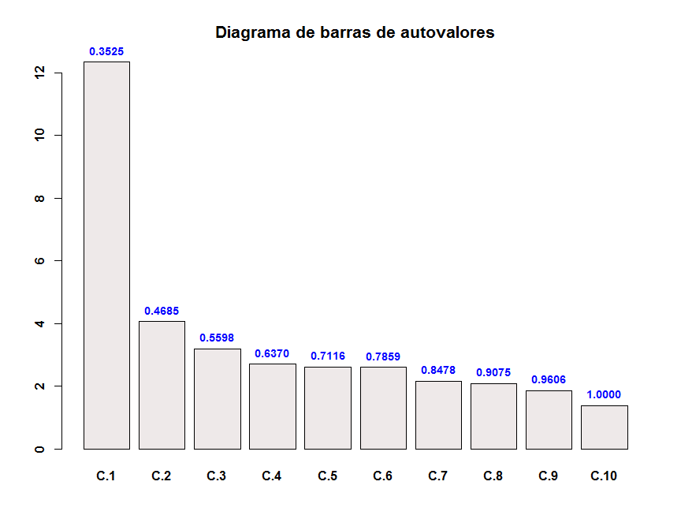

```r
bp = barplot(z,
  col = 'snow2',
  main = 'Diagrama de barras de autovalores',
  font = 2,
  cex.main = 1.3,
  names.arg = paste0('C.',c(1:10)));

text(x = bp, y = z, labels = format(round(u, digits = 4)),
cex = 0.85, pos = 3, xpd = NA, font = 2, col = 4);
```

Las alturas de las barras son las varianzas y las los valores sobre las barras, representan la la **varianza acumulada**.

## 4.7 Conclusiones

- La CP1 es ponderada positivamente para todas las varibles y puede considerarse que describe un tipo de cartera de índices. No suman uno pero, mediante un escalado podría conseguirse.
- La CP2 tiene pesos positivos para las compañías de consumo y pesos negativos para las compañías de tecnología.
- Podrían utilizarse las dos primeras CP para definir los factores de variación aunque sólo consiguen explicar el 46% de la varación y hasta la quinta componente principal no se recoge el 71% de variación.
- La mayor variablilidad es de una cartera promediada, donde se producen coordenadas negativas para las compañias tecnológicas y positivas para las de consumo. Ello llevaría a proponer de venta corta de la tecnología para comprar los títulos de consumo.
- La CP3 parecen mostrar algún tipo de relación o competencia interna entre Microsoft e Intel.